# Risk Factor Analysis

## Outcome Variable

**Outcome Variable:** sstunted

## Predictor Variables

**Intervention Variable:** parity

**Adjustment Set:**

unadjusted

## Stratifying Variables

The analysis was stratified on these variable(s):

- agecat
- studyid
- country

## Data Summary

| agecat | studyid | country | A | n | nA | nAY0 | nAY1 |
| --- | --- | --- | --- | --- | --- | --- | --- |
| Birth | ki1000304b-SAS-CompFeed | INDIA | 1 | 70 | 21 | 20 | 1 |
| Birth | ki1000304b-SAS-CompFeed | INDIA | 2 | 70 | 13 | 11 | 2 |
| Birth | ki1000304b-SAS-CompFeed | INDIA | 3+ | 70 | 36 | 35 | 1 |
| Birth | ki1101329-Keneba | GAMBIA | 1 | 1407 | 156 | 153 | 3 |
| Birth | ki1101329-Keneba | GAMBIA | 2 | 1407 | 146 | 144 | 2 |
| Birth | ki1101329-Keneba | GAMBIA | 3+ | 1407 | 1105 | 1084 | 21 |
| Birth | ki1126311-ZVITAMBO | ZIMBABWE | 1 | 13829 | 5972 | 5777 | 195 |
| Birth | ki1126311-ZVITAMBO | ZIMBABWE | 2 | 13829 | 4125 | 4022 | 103 |
| Birth | ki1126311-ZVITAMBO | ZIMBABWE | 3+ | 13829 | 3732 | 3589 | 143 |
| Birth | ki1135781-COHORTS | GUATEMALA | 1 | 407 | 57 | 56 | 1 |
| Birth | ki1135781-COHORTS | GUATEMALA | 2 | 407 | 70 | 69 | 1 |
| Birth | ki1135781-COHORTS | GUATEMALA | 3+ | 407 | 280 | 278 | 2 |
| Birth | ki1135781-COHORTS | INDIA | 1 | 4122 | 696 | 674 | 22 |
| Birth | ki1135781-COHORTS | INDIA | 2 | 4122 | 1037 | 1016 | 21 |
| Birth | ki1135781-COHORTS | INDIA | 3+ | 4122 | 2389 | 2319 | 70 |
| Birth | ki1135781-COHORTS | PHILIPPINES | 1 | 3050 | 675 | 661 | 14 |
| Birth | ki1135781-COHORTS | PHILIPPINES | 2 | 3050 | 687 | 677 | 10 |
| Birth | ki1135781-COHORTS | PHILIPPINES | 3+ | 3050 | 1688 | 1666 | 22 |
| Birth | kiGH5241-JiVitA-3 | BANGLADESH | 1 | 9734 | 3136 | 2641 | 495 |
| Birth | kiGH5241-JiVitA-3 | BANGLADESH | 2 | 9734 | 3351 | 3045 | 306 |
| Birth | kiGH5241-JiVitA-3 | BANGLADESH | 3+ | 9734 | 3247 | 2952 | 295 |
| 3 months | ki1000304b-SAS-CompFeed | INDIA | 1 | 412 | 114 | 106 | 8 |
| 3 months | ki1000304b-SAS-CompFeed | INDIA | 2 | 412 | 98 | 93 | 5 |
| 3 months | ki1000304b-SAS-CompFeed | INDIA | 3+ | 412 | 200 | 183 | 17 |
| 3 months | ki1000304b-SAS-FoodSuppl | INDIA | 1 | 93 | 17 | 14 | 3 |
| 3 months | ki1000304b-SAS-FoodSuppl | INDIA | 2 | 93 | 19 | 18 | 1 |
| 3 months | ki1000304b-SAS-FoodSuppl | INDIA | 3+ | 93 | 57 | 49 | 8 |
| 3 months | ki1017093b-PROVIDE | BANGLADESH | 1 | 645 | 245 | 240 | 5 |
| 3 months | ki1017093b-PROVIDE | BANGLADESH | 2 | 645 | 227 | 224 | 3 |
| 3 months | ki1017093b-PROVIDE | BANGLADESH | 3+ | 645 | 173 | 171 | 2 |

[output cut: 174 more lines]

The following strata were considered:

- agecat: 12 months, studyid: ki1000304b-SAS-CompFeed, country: INDIA
- agecat: 12 months, studyid: ki1000304b-SAS-FoodSuppl, country: INDIA
- agecat: 12 months, studyid: ki1017093b-PROVIDE, country: BANGLADESH
- agecat: 12 months, studyid: ki1066203-TanzaniaChild2, country: TANZANIA, UNITED REPUBLIC OF
- agecat: 12 months, studyid: ki1101329-Keneba, country: GAMBIA
- agecat: 12 months, studyid: ki1113344-GMS-Nepal, country: NEPAL
- agecat: 12 months, studyid: ki1126311-ZVITAMBO, country: ZIMBABWE
- agecat: 12 months, studyid: ki1135781-COHORTS, country: GUATEMALA
- agecat: 12 months, studyid: ki1135781-COHORTS, country: INDIA
- agecat: 12 months, studyid: ki1135781-COHORTS, country: PHILIPPINES
- agecat: 12 months, studyid: kiGH5241-JiVitA-3, country: BANGLADESH
- agecat: 18 months, studyid: ki1000304b-SAS-CompFeed, country: INDIA
- agecat: 18 months, studyid: ki1000304b-SAS-FoodSuppl, country: INDIA
- agecat: 18 months, studyid: ki1017093b-PROVIDE, country: BANGLADESH
- agecat: 18 months, studyid: ki1066203-TanzaniaChild2, country: TANZANIA, UNITED REPUBLIC OF
- agecat: 18 months, studyid: ki1101329-Keneba, country: GAMBIA
- agecat: 18 months, studyid: ki1113344-GMS-Nepal, country: NEPAL
- agecat: 18 months, studyid: ki1126311-ZVITAMBO, country: ZIMBABWE
- agecat: 18 months, studyid: ki1135781-COHORTS, country: GUATEMALA
- agecat: 18 months, studyid: ki1135781-COHORTS, country: PHILIPPINES
- agecat: 24 months, studyid: ki1017093b-PROVIDE, country: BANGLADESH
- agecat: 24 months, studyid: ki1066203-TanzaniaChild2, country: TANZANIA, UNITED REPUBLIC OF
- agecat: 24 months, studyid: ki1101329-Keneba, country: GAMBIA
- agecat: 24 months, studyid: ki1113344-GMS-Nepal, country: NEPAL
- agecat: 24 months, studyid: ki1126311-ZVITAMBO, country: ZIMBABWE
- agecat: 24 months, studyid: ki1135781-COHORTS, country: GUATEMALA
- agecat: 24 months, studyid: ki1135781-COHORTS, country: INDIA
- agecat: 24 months, studyid: ki1135781-COHORTS, country: PHILIPPINES
- agecat: 24 months, studyid: kiGH5241-JiVitA-3, country: BANGLADESH
- agecat: 3 months, studyid: ki1000304b-SAS-CompFeed, country: INDIA
- agecat: 3 months, studyid: ki1000304b-SAS-FoodSuppl, country: INDIA
- agecat: 3 months, studyid: ki1017093b-PROVIDE, country: BANGLADESH
- agecat: 3 months, studyid: ki1066203-TanzaniaChild2, country: TANZANIA, UNITED REPUBLIC OF
- agecat: 3 months, studyid: ki1101329-Keneba, country: GAMBIA
- agecat: 3 months, studyid: ki1113344-GMS-Nepal, country: NEPAL
- agecat: 3 months, studyid: ki1126311-ZVITAMBO, country: ZIMBABWE
- agecat: 3 months, studyid: ki1135781-COHORTS, country: GUATEMALA
- agecat: 3 months, studyid: ki1135781-COHORTS, country: INDIA
- agecat: 3 months, studyid: ki1135781-COHORTS, country: PHILIPPINES
- agecat: 3 months, studyid: kiGH5241-JiVitA-3, country: BANGLADESH
- agecat: 6 months, studyid: ki1000304b-SAS-CompFeed, country: INDIA
- agecat: 6 months, studyid: ki1000304b-SAS-FoodSuppl, country: INDIA
- agecat: 6 months, studyid: ki1017093b-PROVIDE, country: BANGLADESH
- agecat: 6 months, studyid: ki1066203-TanzaniaChild2, country: TANZANIA, UNITED REPUBLIC OF
- agecat: 6 months, studyid: ki1101329-Keneba, country: GAMBIA
- agecat: 6 months, studyid: ki1113344-GMS-Nepal, country: NEPAL
- agecat: 6 months, studyid: ki1126311-ZVITAMBO, country: ZIMBABWE
- agecat: 6 months, studyid: ki1135781-COHORTS, country: GUATEMALA
- agecat: 6 months, studyid: ki1135781-COHORTS, country: INDIA
- agecat: 6 months, studyid: ki1135781-COHORTS, country: PHILIPPINES
- agecat: 6 months, studyid: kiGH5241-JiVitA-3, country: BANGLADESH
- agecat: 9 months, studyid: ki1000304b-SAS-CompFeed, country: INDIA
- agecat: 9 months, studyid: ki1000304b-SAS-FoodSuppl, country: INDIA
- agecat: 9 months, studyid: ki1017093b-PROVIDE, country: BANGLADESH
- agecat: 9 months, studyid: ki1066203-TanzaniaChild2, country: TANZANIA, UNITED REPUBLIC OF
- agecat: 9 months, studyid: ki1101329-Keneba, country: GAMBIA
- agecat: 9 months, studyid: ki1113344-GMS-Nepal, country: NEPAL
- agecat: 9 months, studyid: ki1126311-ZVITAMBO, country: ZIMBABWE
- agecat: 9 months, studyid: ki1135781-COHORTS, country: GUATEMALA
- agecat: 9 months, studyid: ki1135781-COHORTS, country: INDIA
- agecat: 9 months, studyid: ki1135781-COHORTS, country: PHILIPPINES
- agecat: Birth, studyid: ki1000304b-SAS-CompFeed, country: INDIA
- agecat: Birth, studyid: ki1101329-Keneba, country: GAMBIA
- agecat: Birth, studyid: ki1126311-ZVITAMBO, country: ZIMBABWE
- agecat: Birth, studyid: ki1135781-COHORTS, country: GUATEMALA
- agecat: Birth, studyid: ki1135781-COHORTS, country: INDIA
- agecat: Birth, studyid: ki1135781-COHORTS, country: PHILIPPINES
- agecat: Birth, studyid: kiGH5241-JiVitA-3, country: BANGLADESH

### Dropped Strata

Some strata were dropped due to rare outcomes:

- agecat: Birth, studyid: ki1000304b-SAS-CompFeed, country: INDIA
- agecat: Birth, studyid: ki1101329-Keneba, country: GAMBIA
- agecat: Birth, studyid: ki1135781-COHORTS, country: GUATEMALA
- agecat: 3 months, studyid: ki1000304b-SAS-FoodSuppl, country: INDIA
- agecat: 3 months, studyid: ki1017093b-PROVIDE, country: BANGLADESH
- agecat: 3 months, studyid: ki1101329-Keneba, country: GAMBIA
- agecat: 6 months, studyid: ki1000304b-SAS-FoodSuppl, country: INDIA
- agecat: 6 months, studyid: ki1017093b-PROVIDE, country: BANGLADESH
- agecat: 6 months, studyid: ki1066203-TanzaniaChild2, country: TANZANIA, UNITED REPUBLIC OF
- agecat: 6 months, studyid: ki1101329-Keneba, country: GAMBIA
- agecat: 9 months, studyid: ki1000304b-SAS-FoodSuppl, country: INDIA
- agecat: 9 months, studyid: ki1101329-Keneba, country: GAMBIA
- agecat: 12 months, studyid: ki1101329-Keneba, country: GAMBIA
- agecat: 18 months, studyid: ki1101329-Keneba, country: GAMBIA
- agecat: 24 months, studyid: ki1066203-TanzaniaChild2, country: TANZANIA, UNITED REPUBLIC OF
- agecat: 24 months, studyid: ki1101329-Keneba, country: GAMBIA

## Methods Detail

We’re interested in the causal parameters $E[Y_a]$ for all values of $a \in \mathcal{A}$. These parameters represent the mean outcome if, possibly contrary to fact, we intervened to set all units to have $A=a$. Under the randomization and positivity assumptions, these are identified by the statistical parameters $\psi_a=E_W[E_{Y|A,W}(Y|A=a,W)]$. In addition, we’re interested in the mean of $Y$, $E[Y]$ under no intervention (the observed mean). We will estimate these parameters by using SuperLearner to fit the relevant likelihood factors – $E_{Y|A,W}(Y|A=a,W)$ and $p(A=a|W)$, and then updating our likelihood fit using a joint TMLE.

For unadjusted analyses ($W=\{\}$), initial likelihoods were estimated using Lrnr_glm to estimate the simple $E(Y|A)$ and Lrnr_mean to estimate $p(A)$. For adjusted analyses, a small library containing Lrnr_glmnet, Lrnr_xgboost, and Lrnr_mean was used.

Having estimated these parameters, we will then use the delta method to estimate relative risks and attributable risks relative to a prespecified baseline level of $A$.

# Results Detail

## Results Plots

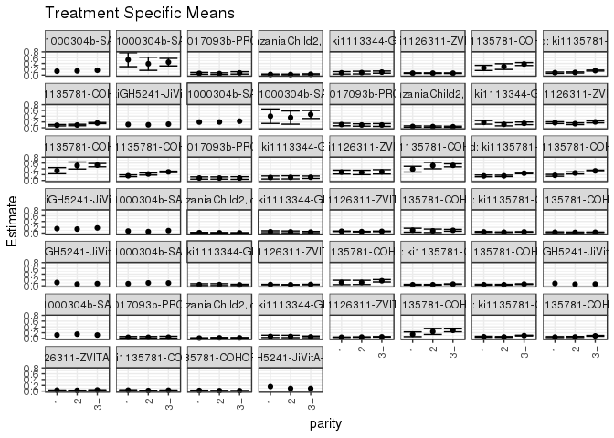

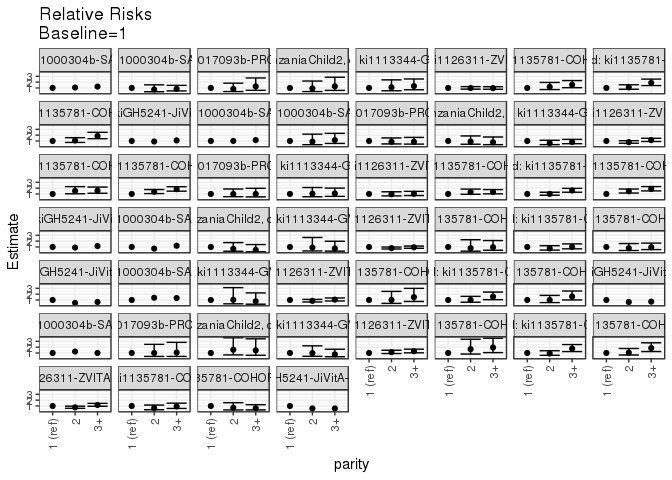

[figure not shown]

[figure not shown]

## Results Table

### Parameter: TSM

| agecat | studyid | country | intervention_level | baseline_level | estimate | ci_lower | ci_upper |
| --- | --- | --- | --- | --- | --- | --- | --- |
| Birth | ki1126311-ZVITAMBO | ZIMBABWE | 1 | NA | 0.0326524 | 0.0281447 | 0.0371601 |
| Birth | ki1126311-ZVITAMBO | ZIMBABWE | 2 | NA | 0.0249697 | 0.0202079 | 0.0297315 |
| Birth | ki1126311-ZVITAMBO | ZIMBABWE | 3+ | NA | 0.0383173 | 0.0321583 | 0.0444762 |
| Birth | ki1135781-COHORTS | INDIA | 1 | NA | 0.0316092 | 0.0186096 | 0.0446087 |
| Birth | ki1135781-COHORTS | INDIA | 2 | NA | 0.0202507 | 0.0116766 | 0.0288248 |
| Birth | ki1135781-COHORTS | INDIA | 3+ | NA | 0.0293010 | 0.0225374 | 0.0360645 |
| Birth | ki1135781-COHORTS | PHILIPPINES | 1 | NA | 0.0207407 | 0.0099878 | 0.0314937 |
| Birth | ki1135781-COHORTS | PHILIPPINES | 2 | NA | 0.0145560 | 0.0055987 | 0.0235134 |
| Birth | ki1135781-COHORTS | PHILIPPINES | 3+ | NA | 0.0130332 | 0.0076218 | 0.0184446 |
| Birth | kiGH5241-JiVitA-3 | BANGLADESH | 1 | NA | 0.1578444 | NA | NA |
| Birth | kiGH5241-JiVitA-3 | BANGLADESH | 2 | NA | 0.0913160 | NA | NA |
| Birth | kiGH5241-JiVitA-3 | BANGLADESH | 3+ | NA | 0.0908531 | NA | NA |
| 3 months | ki1000304b-SAS-CompFeed | INDIA | 1 | NA | 0.0701754 | NA | NA |
| 3 months | ki1000304b-SAS-CompFeed | INDIA | 2 | NA | 0.0510204 | NA | NA |
| 3 months | ki1000304b-SAS-CompFeed | INDIA | 3+ | NA | 0.0850000 | NA | NA |
| 3 months | ki1066203-TanzaniaChild2 | TANZANIA, UNITED REPUBLIC OF | 1 | NA | 0.0138714 | 0.0057293 | 0.0220134 |
| 3 months | ki1066203-TanzaniaChild2 | TANZANIA, UNITED REPUBLIC OF | 2 | NA | 0.0094595 | 0.0024836 | 0.0164353 |
| 3 months | ki1066203-TanzaniaChild2 | TANZANIA, UNITED REPUBLIC OF | 3+ | NA | 0.0068493 | 0.0008650 | 0.0128336 |
| 3 months | ki1113344-GMS-Nepal | NEPAL | 1 | NA | 0.0448718 | 0.0123568 | 0.0773868 |
| 3 months | ki1113344-GMS-Nepal | NEPAL | 2 | NA | 0.0405405 | 0.0087384 | 0.0723427 |
| 3 months | ki1113344-GMS-Nepal | NEPAL | 3+ | NA | 0.0337079 | 0.0120412 | 0.0553746 |
| 3 months | ki1126311-ZVITAMBO | ZIMBABWE | 1 | NA | 0.0619035 | 0.0541034 | 0.0697035 |
| 3 months | ki1126311-ZVITAMBO | ZIMBABWE | 2 | NA | 0.0497512 | 0.0417173 | 0.0577852 |
| 3 months | ki1126311-ZVITAMBO | ZIMBABWE | 3+ | NA | 0.0586499 | 0.0498046 | 0.0674953 |
| 3 months | ki1135781-COHORTS | GUATEMALA | 1 | NA | 0.0985915 | 0.0291758 | 0.1680073 |
| 3 months | ki1135781-COHORTS | GUATEMALA | 2 | NA | 0.0779221 | 0.0179878 | 0.1378564 |
| 3 months | ki1135781-COHORTS | GUATEMALA | 3+ | NA | 0.0950920 | 0.0632154 | 0.1269686 |
| 3 months | ki1135781-COHORTS | INDIA | 1 | NA | 0.0391892 | 0.0252067 | 0.0531717 |
| 3 months | ki1135781-COHORTS | INDIA | 2 | NA | 0.0294118 | 0.0195244 | 0.0392991 |
| 3 months | ki1135781-COHORTS | INDIA | 3+ | NA | 0.0398406 | 0.0321883 | 0.0474930 |

[output cut: 126 more lines]

### Parameter: E(Y)

| agecat | studyid | country | intervention_level | baseline_level | estimate | ci_lower | ci_upper |
| --- | --- | --- | --- | --- | --- | --- | --- |
| Birth | ki1126311-ZVITAMBO | ZIMBABWE | NA | NA | 0.0318895 | 0.0289609 | 0.0348181 |
| Birth | ki1135781-COHORTS | INDIA | NA | NA | 0.0274139 | 0.0224285 | 0.0323992 |
| Birth | ki1135781-COHORTS | PHILIPPINES | NA | NA | 0.0150820 | 0.0107558 | 0.0194081 |
| Birth | kiGH5241-JiVitA-3 | BANGLADESH | NA | NA | 0.1125950 | NA | NA |
| 3 months | ki1000304b-SAS-CompFeed | INDIA | NA | NA | 0.0728155 | NA | NA |
| 3 months | ki1066203-TanzaniaChild2 | TANZANIA, UNITED REPUBLIC OF | NA | NA | 0.0101635 | 0.0060301 | 0.0142969 |
| 3 months | ki1113344-GMS-Nepal | NEPAL | NA | NA | 0.0385289 | 0.0227284 | 0.0543294 |
| 3 months | ki1126311-ZVITAMBO | ZIMBABWE | NA | NA | 0.0572237 | 0.0524751 | 0.0619722 |
| 3 months | ki1135781-COHORTS | GUATEMALA | NA | NA | 0.0928270 | 0.0666753 | 0.1189787 |
| 3 months | ki1135781-COHORTS | INDIA | NA | NA | 0.0370540 | 0.0314541 | 0.0426538 |
| 3 months | ki1135781-COHORTS | PHILIPPINES | NA | NA | 0.0257391 | 0.0199497 | 0.0315286 |
| 3 months | kiGH5241-JiVitA-3 | BANGLADESH | NA | NA | 0.0833808 | NA | NA |
| 6 months | ki1000304b-SAS-CompFeed | INDIA | NA | NA | 0.0900243 | NA | NA |
| 6 months | ki1113344-GMS-Nepal | NEPAL | NA | NA | 0.0355240 | 0.0202206 | 0.0508273 |
| 6 months | ki1126311-ZVITAMBO | ZIMBABWE | NA | NA | 0.0417169 | 0.0374137 | 0.0460201 |
| 6 months | ki1135781-COHORTS | GUATEMALA | NA | NA | 0.1551724 | 0.1221925 | 0.1881523 |
| 6 months | ki1135781-COHORTS | INDIA | NA | NA | 0.0484735 | 0.0420469 | 0.0549002 |
| 6 months | ki1135781-COHORTS | PHILIPPINES | NA | NA | 0.0487445 | 0.0406327 | 0.0568562 |
| 6 months | kiGH5241-JiVitA-3 | BANGLADESH | NA | NA | 0.0659129 | NA | NA |
| 9 months | ki1000304b-SAS-CompFeed | INDIA | NA | NA | 0.1262376 | NA | NA |
| 9 months | ki1017093b-PROVIDE | BANGLADESH | NA | NA | 0.0413223 | 0.0254493 | 0.0571953 |
| 9 months | ki1066203-TanzaniaChild2 | TANZANIA, UNITED REPUBLIC OF | NA | NA | 0.0192744 | 0.0128566 | 0.0256922 |
| 9 months | ki1113344-GMS-Nepal | NEPAL | NA | NA | 0.0635209 | 0.0431376 | 0.0839041 |
| 9 months | ki1126311-ZVITAMBO | ZIMBABWE | NA | NA | 0.0480844 | 0.0432974 | 0.0528715 |
| 9 months | ki1135781-COHORTS | GUATEMALA | NA | NA | 0.2538631 | 0.2137406 | 0.2939856 |
| 9 months | ki1135781-COHORTS | INDIA | NA | NA | 0.0806580 | 0.0719633 | 0.0893527 |
| 9 months | ki1135781-COHORTS | PHILIPPINES | NA | NA | 0.0722714 | 0.0625243 | 0.0820185 |
| 12 months | ki1000304b-SAS-CompFeed | INDIA | NA | NA | 0.1521739 | NA | NA |
| 12 months | ki1000304b-SAS-FoodSuppl | INDIA | NA | NA | 0.4505495 | 0.3477567 | 0.5533422 |
| 12 months | ki1017093b-PROVIDE | BANGLADESH | NA | NA | 0.0600000 | 0.0409816 | 0.0790184 |
| 12 months | ki1066203-TanzaniaChild2 | TANZANIA, UNITED REPUBLIC OF | NA | NA | 0.0232068 | 0.0153786 | 0.0310349 |
| 12 months | ki1113344-GMS-Nepal | NEPAL | NA | NA | 0.0913978 | 0.0674660 | 0.1153296 |
| 12 months | ki1126311-ZVITAMBO | ZIMBABWE | NA | NA | 0.0662418 | 0.0603075 | 0.0721762 |
| 12 months | ki1135781-COHORTS | GUATEMALA | NA | NA | 0.3452158 | 0.3048153 | 0.3856163 |
| 12 months | ki1135781-COHORTS | INDIA | NA | NA | 0.1262079 | 0.1150685 | 0.1373474 |
| 12 months | ki1135781-COHORTS | PHILIPPINES | NA | NA | 0.1330754 | 0.1199794 | 0.1461715 |
| 12 months | kiGH5241-JiVitA-3 | BANGLADESH | NA | NA | 0.1137026 | NA | NA |
| 18 months | ki1000304b-SAS-CompFeed | INDIA | NA | NA | 0.2126582 | NA | NA |
| 18 months | ki1000304b-SAS-FoodSuppl | INDIA | NA | NA | 0.4268293 | 0.3191146 | 0.5345439 |
| 18 months | ki1017093b-PROVIDE | BANGLADESH | NA | NA | 0.1032609 | 0.0778527 | 0.1286690 |
| 18 months | ki1066203-TanzaniaChild2 | TANZANIA, UNITED REPUBLIC OF | NA | NA | 0.0403727 | 0.0279539 | 0.0527915 |
| 18 months | ki1113344-GMS-Nepal | NEPAL | NA | NA | 0.1545455 | 0.1243087 | 0.1847822 |
| 18 months | ki1126311-ZVITAMBO | ZIMBABWE | NA | NA | 0.1743710 | 0.1563767 | 0.1923652 |
| 18 months | ki1135781-COHORTS | GUATEMALA | NA | NA | 0.4931193 | 0.4461372 | 0.5401014 |
| 18 months | ki1135781-COHORTS | PHILIPPINES | NA | NA | 0.2516051 | 0.2345645 | 0.2686458 |
| 24 months | ki1017093b-PROVIDE | BANGLADESH | NA | NA | 0.0849220 | 0.0621566 | 0.1076874 |
| 24 months | ki1113344-GMS-Nepal | NEPAL | NA | NA | 0.1082164 | 0.0809323 | 0.1355005 |
| 24 months | ki1126311-ZVITAMBO | ZIMBABWE | NA | NA | 0.2872807 | 0.2457035 | 0.3288579 |
| 24 months | ki1135781-COHORTS | GUATEMALA | NA | NA | 0.4961390 | 0.4530407 | 0.5392373 |
| 24 months | ki1135781-COHORTS | INDIA | NA | NA | 0.2122377 | 0.1984570 | 0.2260183 |
| 24 months | ki1135781-COHORTS | PHILIPPINES | NA | NA | 0.2817996 | 0.2639639 | 0.2996353 |
| 24 months | kiGH5241-JiVitA-3 | BANGLADESH | NA | NA | 0.1553172 | NA | NA |

### Parameter: RR

| agecat | studyid | country | intervention_level | baseline_level | estimate | ci_lower | ci_upper |
| --- | --- | --- | --- | --- | --- | --- | --- |
| Birth | ki1126311-ZVITAMBO | ZIMBABWE | 1 | 1 | 1.0000000 | 1.0000000 | 1.0000000 |
| Birth | ki1126311-ZVITAMBO | ZIMBABWE | 2 | 1 | 0.7647130 | 0.6043028 | 0.9677035 |
| Birth | ki1126311-ZVITAMBO | ZIMBABWE | 3+ | 1 | 1.1734905 | 0.9494248 | 1.4504361 |
| Birth | ki1135781-COHORTS | INDIA | 1 | 1 | 1.0000000 | 1.0000000 | 1.0000000 |
| Birth | ki1135781-COHORTS | INDIA | 2 | 1 | 0.6406592 | 0.3550449 | 1.1560348 |
| Birth | ki1135781-COHORTS | INDIA | 3+ | 1 | 0.9269759 | 0.5784298 | 1.4855465 |
| Birth | ki1135781-COHORTS | PHILIPPINES | 1 | 1 | 1.0000000 | 1.0000000 | 1.0000000 |
| Birth | ki1135781-COHORTS | PHILIPPINES | 2 | 1 | 0.7018091 | 0.3138795 | 1.5691883 |
| Birth | ki1135781-COHORTS | PHILIPPINES | 3+ | 1 | 0.6283852 | 0.3234162 | 1.2209285 |
| Birth | kiGH5241-JiVitA-3 | BANGLADESH | 1 | 1 | 1.0000000 | NA | NA |
| Birth | kiGH5241-JiVitA-3 | BANGLADESH | 2 | 1 | 0.5785193 | NA | NA |
| Birth | kiGH5241-JiVitA-3 | BANGLADESH | 3+ | 1 | 0.5755865 | NA | NA |
| 3 months | ki1000304b-SAS-CompFeed | INDIA | 1 | 1 | 1.0000000 | NA | NA |
| 3 months | ki1000304b-SAS-CompFeed | INDIA | 2 | 1 | 0.7270408 | NA | NA |
| 3 months | ki1000304b-SAS-CompFeed | INDIA | 3+ | 1 | 1.2112500 | NA | NA |
| 3 months | ki1066203-TanzaniaChild2 | TANZANIA, UNITED REPUBLIC OF | 1 | 1 | 1.0000000 | 1.0000000 | 1.0000000 |
| 3 months | ki1066203-TanzaniaChild2 | TANZANIA, UNITED REPUBLIC OF | 2 | 1 | 0.6819410 | 0.2657124 | 1.7501766 |
| 3 months | ki1066203-TanzaniaChild2 | TANZANIA, UNITED REPUBLIC OF | 3+ | 1 | 0.4937734 | 0.1723469 | 1.4146595 |
| 3 months | ki1113344-GMS-Nepal | NEPAL | 1 | 1 | 1.0000000 | 1.0000000 | 1.0000000 |
| 3 months | ki1113344-GMS-Nepal | NEPAL | 2 | 1 | 0.9034749 | 0.3105468 | 2.6284827 |
| 3 months | ki1113344-GMS-Nepal | NEPAL | 3+ | 1 | 0.7512039 | 0.2851597 | 1.9789164 |
| 3 months | ki1126311-ZVITAMBO | ZIMBABWE | 1 | 1 | 1.0000000 | 1.0000000 | 1.0000000 |
| 3 months | ki1126311-ZVITAMBO | ZIMBABWE | 2 | 1 | 0.8036908 | 0.6548387 | 0.9863787 |
| 3 months | ki1126311-ZVITAMBO | ZIMBABWE | 3+ | 1 | 0.9474421 | 0.7783994 | 1.1531952 |
| 3 months | ki1135781-COHORTS | GUATEMALA | 1 | 1 | 1.0000000 | 1.0000000 | 1.0000000 |
| 3 months | ki1135781-COHORTS | GUATEMALA | 2 | 1 | 0.7903525 | 0.2785873 | 2.2422313 |
| 3 months | ki1135781-COHORTS | GUATEMALA | 3+ | 1 | 0.9645048 | 0.4422221 | 2.1036252 |
| 3 months | ki1135781-COHORTS | INDIA | 1 | 1 | 1.0000000 | 1.0000000 | 1.0000000 |
| 3 months | ki1135781-COHORTS | INDIA | 2 | 1 | 0.7505071 | 0.4596810 | 1.2253299 |
| 3 months | ki1135781-COHORTS | INDIA | 3+ | 1 | 1.0166232 | 0.6779221 | 1.5245448 |

[output cut: 126 more lines]

### Parameter: PAR

| agecat | studyid | country | intervention_level | baseline_level | estimate | ci_lower | ci_upper |
| --- | --- | --- | --- | --- | --- | --- | --- |
| Birth | ki1126311-ZVITAMBO | ZIMBABWE | 1 | NA | -0.0007629 | -0.0041313 | 0.0026055 |
| Birth | ki1135781-COHORTS | INDIA | 1 | NA | -0.0041953 | -0.0158904 | 0.0074997 |
| Birth | ki1135781-COHORTS | PHILIPPINES | 1 | NA | -0.0056588 | -0.0147781 | 0.0034606 |
| Birth | kiGH5241-JiVitA-3 | BANGLADESH | 1 | NA | -0.0452494 | NA | NA |
| 3 months | ki1000304b-SAS-CompFeed | INDIA | 1 | NA | 0.0026401 | NA | NA |
| 3 months | ki1066203-TanzaniaChild2 | TANZANIA, UNITED REPUBLIC OF | 1 | NA | -0.0037079 | -0.0097838 | 0.0023681 |
| 3 months | ki1113344-GMS-Nepal | NEPAL | 1 | NA | -0.0063429 | -0.0333467 | 0.0206609 |
| 3 months | ki1126311-ZVITAMBO | ZIMBABWE | 1 | NA | -0.0046798 | -0.0105829 | 0.0012233 |
| 3 months | ki1135781-COHORTS | GUATEMALA | 1 | NA | -0.0057645 | -0.0694743 | 0.0579452 |
| 3 months | ki1135781-COHORTS | INDIA | 1 | NA | -0.0021352 | -0.0148113 | 0.0105409 |
| 3 months | ki1135781-COHORTS | PHILIPPINES | 1 | NA | -0.0019482 | -0.0133516 | 0.0094553 |
| 3 months | kiGH5241-JiVitA-3 | BANGLADESH | 1 | NA | -0.0311499 | NA | NA |
| 6 months | ki1000304b-SAS-CompFeed | INDIA | 1 | NA | 0.0174437 | NA | NA |
| 6 months | ki1113344-GMS-Nepal | NEPAL | 1 | NA | -0.0036917 | -0.0295140 | 0.0221306 |
| 6 months | ki1126311-ZVITAMBO | ZIMBABWE | 1 | NA | -0.0012873 | -0.0066047 | 0.0040301 |
| 6 months | ki1135781-COHORTS | GUATEMALA | 1 | NA | 0.0392304 | -0.0322233 | 0.1106841 |
| 6 months | ki1135781-COHORTS | INDIA | 1 | NA | 0.0119871 | -0.0006968 | 0.0246710 |
| 6 months | ki1135781-COHORTS | PHILIPPINES | 1 | NA | 0.0121591 | -0.0020444 | 0.0263626 |
| 6 months | kiGH5241-JiVitA-3 | BANGLADESH | 1 | NA | -0.0162277 | NA | NA |
| 9 months | ki1000304b-SAS-CompFeed | INDIA | 1 | NA | 0.0065795 | NA | NA |
| 9 months | ki1017093b-PROVIDE | BANGLADESH | 1 | NA | 0.0007818 | -0.0199875 | 0.0215510 |
| 9 months | ki1066203-TanzaniaChild2 | TANZANIA, UNITED REPUBLIC OF | 1 | NA | 0.0047582 | -0.0034596 | 0.0129760 |
| 9 months | ki1113344-GMS-Nepal | NEPAL | 1 | NA | -0.0083746 | -0.0424592 | 0.0257101 |
| 9 months | ki1126311-ZVITAMBO | ZIMBABWE | 1 | NA | 0.0057199 | -0.0000664 | 0.0115062 |
| 9 months | ki1135781-COHORTS | GUATEMALA | 1 | NA | 0.1089356 | 0.0288237 | 0.1890475 |
| 9 months | ki1135781-COHORTS | INDIA | 1 | NA | 0.0233825 | 0.0064511 | 0.0403138 |
| 9 months | ki1135781-COHORTS | PHILIPPINES | 1 | NA | 0.0239955 | 0.0075877 | 0.0404033 |
| 12 months | ki1000304b-SAS-CompFeed | INDIA | 1 | NA | 0.0172533 | NA | NA |
| 12 months | ki1000304b-SAS-FoodSuppl | INDIA | 1 | NA | -0.0788623 | -0.2938526 | 0.1361280 |
| 12 months | ki1017093b-PROVIDE | BANGLADESH | 1 | NA | 0.0006393 | -0.0243925 | 0.0256710 |
| 12 months | ki1066203-TanzaniaChild2 | TANZANIA, UNITED REPUBLIC OF | 1 | NA | 0.0014246 | -0.0089809 | 0.0118301 |
| 12 months | ki1113344-GMS-Nepal | NEPAL | 1 | NA | 0.0139785 | -0.0229118 | 0.0508688 |
| 12 months | ki1126311-ZVITAMBO | ZIMBABWE | 1 | NA | -0.0008267 | -0.0082123 | 0.0065588 |
| 12 months | ki1135781-COHORTS | GUATEMALA | 1 | NA | 0.0980247 | 0.0144072 | 0.1816423 |
| 12 months | ki1135781-COHORTS | INDIA | 1 | NA | 0.0440161 | 0.0227870 | 0.0652453 |
| 12 months | ki1135781-COHORTS | PHILIPPINES | 1 | NA | 0.0446278 | 0.0224679 | 0.0667877 |
| 12 months | kiGH5241-JiVitA-3 | BANGLADESH | 1 | NA | -0.0005199 | NA | NA |
| 18 months | ki1000304b-SAS-CompFeed | INDIA | 1 | NA | 0.0143111 | NA | NA |
| 18 months | ki1000304b-SAS-FoodSuppl | INDIA | 1 | NA | 0.0268293 | -0.1991362 | 0.2527947 |
| 18 months | ki1017093b-PROVIDE | BANGLADESH | 1 | NA | -0.0100396 | -0.0439412 | 0.0238620 |
| 18 months | ki1066203-TanzaniaChild2 | TANZANIA, UNITED REPUBLIC OF | 1 | NA | -0.0046724 | -0.0222364 | 0.0128916 |
| 18 months | ki1113344-GMS-Nepal | NEPAL | 1 | NA | -0.0325513 | -0.0831683 | 0.0180656 |
| 18 months | ki1126311-ZVITAMBO | ZIMBABWE | 1 | NA | -0.0021915 | -0.0254935 | 0.0211104 |
| 18 months | ki1135781-COHORTS | GUATEMALA | 1 | NA | 0.1554569 | 0.0582949 | 0.2526190 |
| 18 months | ki1135781-COHORTS | PHILIPPINES | 1 | NA | 0.0890342 | 0.0597169 | 0.1183516 |
| 24 months | ki1017093b-PROVIDE | BANGLADESH | 1 | NA | -0.0003860 | -0.0303952 | 0.0296231 |
| 24 months | ki1113344-GMS-Nepal | NEPAL | 1 | NA | 0.0052753 | -0.0386949 | 0.0492454 |
| 24 months | ki1126311-ZVITAMBO | ZIMBABWE | 1 | NA | -0.0008549 | -0.0530718 | 0.0513620 |
| 24 months | ki1135781-COHORTS | GUATEMALA | 1 | NA | 0.1066653 | 0.0174600 | 0.1958706 |
| 24 months | ki1135781-COHORTS | INDIA | 1 | NA | 0.0547155 | 0.0265910 | 0.0828401 |
| 24 months | ki1135781-COHORTS | PHILIPPINES | 1 | NA | 0.1043187 | 0.0738254 | 0.1348119 |
| 24 months | kiGH5241-JiVitA-3 | BANGLADESH | 1 | NA | 0.0014710 | NA | NA |

### Parameter: PAF

| agecat | studyid | country | intervention_level | baseline_level | estimate | ci_lower | ci_upper |
| --- | --- | --- | --- | --- | --- | --- | --- |
| Birth | ki1126311-ZVITAMBO | ZIMBABWE | 1 | NA | -0.0239223 | -0.1351665 | 0.0764202 |
| Birth | ki1135781-COHORTS | INDIA | 1 | NA | -0.1530363 | -0.6680434 | 0.2029627 |
| Birth | ki1135781-COHORTS | PHILIPPINES | 1 | NA | -0.3752013 | -1.1203069 | 0.1080637 |
| Birth | kiGH5241-JiVitA-3 | BANGLADESH | 1 | NA | -0.4018771 | NA | NA |
| 3 months | ki1000304b-SAS-CompFeed | INDIA | 1 | NA | 0.0362573 | NA | NA |
| 3 months | ki1066203-TanzaniaChild2 | TANZANIA, UNITED REPUBLIC OF | 1 | NA | -0.3648226 | -1.0870059 | 0.1074578 |
| 3 months | ki1113344-GMS-Nepal | NEPAL | 1 | NA | -0.1646270 | -1.1205233 | 0.3603673 |
| 3 months | ki1126311-ZVITAMBO | ZIMBABWE | 1 | NA | -0.0817807 | -0.1898040 | 0.0164351 |
| 3 months | ki1135781-COHORTS | GUATEMALA | 1 | NA | -0.0620999 | -1.0264434 | 0.4433320 |
| 3 months | ki1135781-COHORTS | INDIA | 1 | NA | -0.0576243 | -0.4613911 | 0.2345861 |
| 3 months | ki1135781-COHORTS | PHILIPPINES | 1 | NA | -0.0756889 | -0.6234289 | 0.2872453 |
| 3 months | kiGH5241-JiVitA-3 | BANGLADESH | 1 | NA | -0.3735858 | NA | NA |
| 6 months | ki1000304b-SAS-CompFeed | INDIA | 1 | NA | 0.1937663 | NA | NA |
| 6 months | ki1113344-GMS-Nepal | NEPAL | 1 | NA | -0.1039216 | -1.1301455 | 0.4279063 |
| 6 months | ki1126311-ZVITAMBO | ZIMBABWE | 1 | NA | -0.0308589 | -0.1664975 | 0.0890079 |
| 6 months | ki1135781-COHORTS | GUATEMALA | 1 | NA | 0.2528180 | -0.3795947 | 0.5953298 |
| 6 months | ki1135781-COHORTS | INDIA | 1 | NA | 0.2472908 | -0.0629283 | 0.4669715 |
| 6 months | ki1135781-COHORTS | PHILIPPINES | 1 | NA | 0.2494457 | -0.1025563 | 0.4890676 |
| 6 months | kiGH5241-JiVitA-3 | BANGLADESH | 1 | NA | -0.2461993 | NA | NA |
| 9 months | ki1000304b-SAS-CompFeed | INDIA | 1 | NA | 0.0521200 | NA | NA |
| 9 months | ki1017093b-PROVIDE | BANGLADESH | 1 | NA | 0.0189189 | -0.6374810 | 0.4121946 |
| 9 months | ki1066203-TanzaniaChild2 | TANZANIA, UNITED REPUBLIC OF | 1 | NA | 0.2468691 | -0.3129746 | 0.5679991 |
| 9 months | ki1113344-GMS-Nepal | NEPAL | 1 | NA | -0.1318394 | -0.8160834 | 0.2946026 |
| 9 months | ki1126311-ZVITAMBO | ZIMBABWE | 1 | NA | 0.1189555 | -0.0093768 | 0.2309716 |
| 9 months | ki1135781-COHORTS | GUATEMALA | 1 | NA | 0.4291115 | 0.0155301 | 0.6689450 |
| 9 months | ki1135781-COHORTS | INDIA | 1 | NA | 0.2898963 | 0.0484028 | 0.4701043 |
| 9 months | ki1135781-COHORTS | PHILIPPINES | 1 | NA | 0.3320197 | 0.0672296 | 0.5216425 |
| 12 months | ki1000304b-SAS-CompFeed | INDIA | 1 | NA | 0.1133787 | NA | NA |
| 12 months | ki1000304b-SAS-FoodSuppl | INDIA | 1 | NA | -0.1750359 | -0.7659835 | 0.2181641 |
| 12 months | ki1017093b-PROVIDE | BANGLADESH | 1 | NA | 0.0106545 | -0.5082724 | 0.3510426 |
| 12 months | ki1066203-TanzaniaChild2 | TANZANIA, UNITED REPUBLIC OF | 1 | NA | 0.0613861 | -0.5126585 | 0.4175844 |
| 12 months | ki1113344-GMS-Nepal | NEPAL | 1 | NA | 0.1529412 | -0.3614693 | 0.4729895 |
| 12 months | ki1126311-ZVITAMBO | ZIMBABWE | 1 | NA | -0.0124804 | -0.1303392 | 0.0930894 |
| 12 months | ki1135781-COHORTS | GUATEMALA | 1 | NA | 0.2839521 | -0.0034882 | 0.4890577 |
| 12 months | ki1135781-COHORTS | INDIA | 1 | NA | 0.3487589 | 0.1598061 | 0.4952177 |
| 12 months | ki1135781-COHORTS | PHILIPPINES | 1 | NA | 0.3353570 | 0.1494828 | 0.4806098 |
| 12 months | kiGH5241-JiVitA-3 | BANGLADESH | 1 | NA | -0.0045727 | NA | NA |
| 18 months | ki1000304b-SAS-CompFeed | INDIA | 1 | NA | 0.0672963 | NA | NA |
| 18 months | ki1000304b-SAS-FoodSuppl | INDIA | 1 | NA | 0.0628571 | -0.6488770 | 0.4673728 |
| 18 months | ki1017093b-PROVIDE | BANGLADESH | 1 | NA | -0.0972258 | -0.4790637 | 0.1860361 |
| 18 months | ki1066203-TanzaniaChild2 | TANZANIA, UNITED REPUBLIC OF | 1 | NA | -0.1157311 | -0.6458324 | 0.2436314 |
| 18 months | ki1113344-GMS-Nepal | NEPAL | 1 | NA | -0.2106262 | -0.5848351 | 0.0752251 |
| 18 months | ki1126311-ZVITAMBO | ZIMBABWE | 1 | NA | -0.0125682 | -0.1554176 | 0.1126201 |
| 18 months | ki1135781-COHORTS | GUATEMALA | 1 | NA | 0.3152522 | 0.0859286 | 0.4870427 |
| 18 months | ki1135781-COHORTS | PHILIPPINES | 1 | NA | 0.3538650 | 0.2278538 | 0.4593117 |
| 24 months | ki1017093b-PROVIDE | BANGLADESH | 1 | NA | -0.0045459 | -0.4280475 | 0.2933621 |
| 24 months | ki1113344-GMS-Nepal | NEPAL | 1 | NA | 0.0487473 | -0.4579228 | 0.3793349 |
| 24 months | ki1126311-ZVITAMBO | ZIMBABWE | 1 | NA | -0.0029758 | -0.2022498 | 0.1632683 |
| 24 months | ki1135781-COHORTS | GUATEMALA | 1 | NA | 0.2149908 | 0.0122698 | 0.3761055 |
| 24 months | ki1135781-COHORTS | INDIA | 1 | NA | 0.2578031 | 0.1134822 | 0.3786293 |
| 24 months | ki1135781-COHORTS | PHILIPPINES | 1 | NA | 0.3701875 | 0.2536575 | 0.4685230 |
| 24 months | kiGH5241-JiVitA-3 | BANGLADESH | 1 | NA | 0.0094710 | NA | NA |